# Financing College: Anatomy of Parent PLUS Loans

Rhowena Vespa RPh, MBA  
2022-05-12

```r
library(distill)
library(dplyr)
library(readr)
library(tidyverse)
library(knitr)
library(ggplot2)
library("readxl")
```

# BACKGROUND

# RESEARCH AND METHODS

*This multifaceted study uses quantitative methods to examine the characteristics of parent PLUS loans including demographic profiles, loan amounts, type of borrowers, and analyze trends on repayment and default rates from over 800 post-secondary schools in the US.*

```
        METHODS:
        -Data is sourced from March 2022  US Department of Education
        College Scorecard
        -Missing Not At Random (MNAR) data (e.g. NULL, Privacy
        Suppressed) was handled using listwise deletion. Imputation
        of MNAR is not preferred as it will give misleading results
        -Exploratory data analysis, data visualization and
        descriptive statistics.
        -Correlation Matrix to evaluate strongly correlated variables
        -Simple and multiple regression analyses
        -Post hoc test using EMM (Estimated Marginal Means)
        -Diagnostic Plots evaluation of regression model
```

## Data

```r
loans<- read_excel("LOANS.xlsx",)
Eloans <-na.omit(loans)
```

```r
Eloans<-rename(Eloans, State=STABBR)
```

```r
Eloans<-rename(Eloans,SAT=SAT_AVG)
```

```r
Eloans<-  rename(Eloans,COST=COSTT4_A)
```

```r
Eloans <-rename(Eloans,Students=LPPPLUS_CNT)
```

```r
Eloans<-  rename(Eloans,Repay5yr=DBRR5_PP_UG_RT)
```

```r
Eloans<-  rename(Eloans,Repay10yr=DBRR10_PP_UG_RT)
```

```r
Eloans<-  rename(Eloans,Repay20yr=DBRR20_PP_UG_RT)
```

```r
Eloans<-  rename(Eloans,ParentLoan=PLUS_DEBT_INST_MD)
```

```r
Eloans<-  rename(Eloans,StudentLoan=DEBT_MDN )
```

```r
Eloans<-rename(Eloans, Default3yr=BBRR3_PP_UG_DFLT)
```

```r
Eloans<-  rename(Eloans,NoDegree=OMENRUP_ALL_POOLED_SUPP)
```

```r
Eloans<-rename(Eloans, PellBorrowerLoan=PLUS_DEBT_INST_PELL_MD)
```

```r
Eloans<-  rename(Eloans,NoPellBorrowerLoan=PLUS_DEBT_INST_NOPELL_MD)
```

```r
Eloans<-rename(Eloans,Parents=BBRR1_PP_UG_N)
```

```r
dim(Eloans)
```

```
[1] 865  35
```

### Sum of Total outstanding Parent PLUS Loan balance

```r
TPL<-sum(Eloans$LPPPLUS_AMT)
print(paste("Total outstanding Parent PLUS Loan balance is",TPL))
```

```
[1] "Total outstanding Parent PLUS Loan balance is 84303788470"
```

### Sum of Number of students associated with outstanding Parent PLUS Loan balances

```r
TSL<-sum(Eloans$Students)
print(paste("Total Number of students associated with outstanding Parent PLUS Loan balances is", TSL))
```

```
[1] "Total Number of students associated with outstanding Parent PLUS Loan balances is 2730197"
```

# LOAN DISTRIBUTION ACROSS THE US

### Fig 1. Who is borrowing how much?

Method: Descriptive Statistics

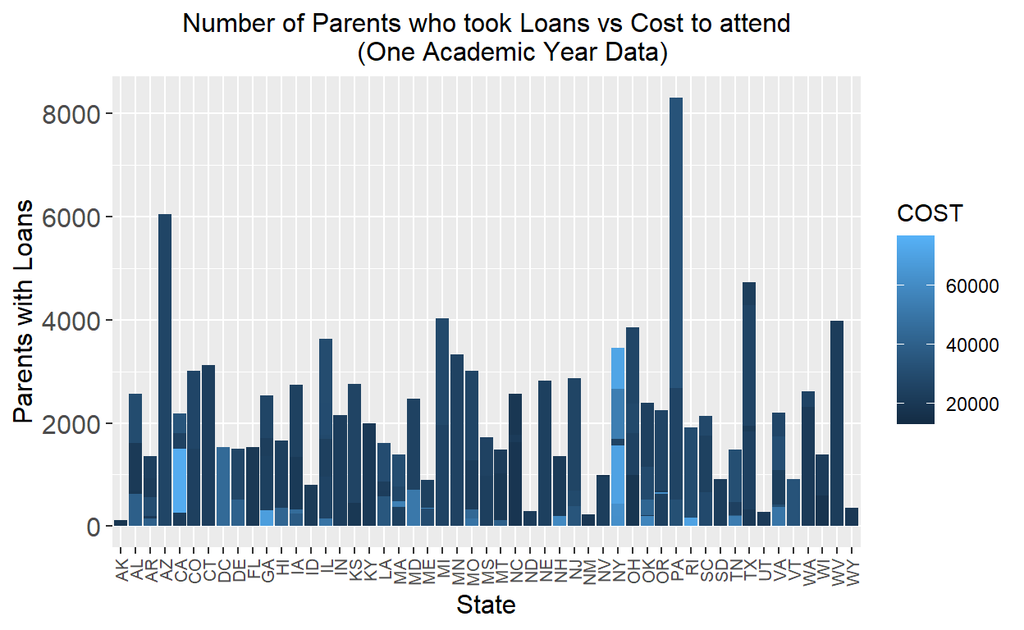

```r
ggplot(Eloans, aes(x = State , y= Parents, fill = COST)) +
  geom_bar(position="dodge",stat = "identity") +
  labs(x = "State",
       y = "Parents with Loans",
       title = "Number of Parents who took Loans vs Cost to attend
       (One Academic Year Data)") +
  theme(axis.text.x = element_text(angle = 90, vjust = 0.5, hjust=1,size=8),
        axis.text.y = element_text(size=12),
        axis.title.y = element_text(size=12),
        axis.title.x = element_text(size=12),
        plot.title = element_text(size=12,hjust=0.5))
```

### Observation

[output not shown]

# LOAN AMOUNTS AND SCHOOL SELECTIVITY

### Fig 2. Where are the loans disbursed?

Method: Regression Analysis

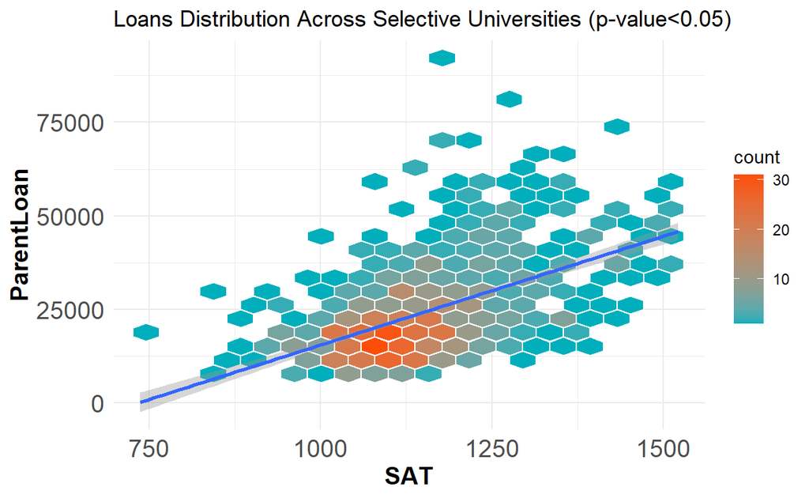

```r
library(hexbin)
ggplot(Eloans, aes(SAT, ParentLoan)) +
  geom_hex(bins = 20, color = "white")+
  scale_fill_gradient(low =  "#00AFBB", high = "#FC4E07")+
  theme_minimal() +
  geom_smooth(method = "lm") +
ggtitle( "Loans Distribution Across Selective Universities (p-value<0.05)" )+
  theme(axis.text=element_text(size=14),
        axis.title=element_text(size=14,face="bold"))
```

```r
SAT_lm<-lm(ParentLoan~SAT,Eloans)
summary(SAT_lm)
```

```
Call:
lm(formula = ParentLoan ~ SAT, data = Eloans)

Residuals:
   Min     1Q Median     3Q    Max
-21865  -6885  -1560   4992  66762

Coefficients:
              Estimate Std. Error t value Pr(>|t|)
(Intercept) -42600.486   3577.839  -11.91   <2e-16 ***
SAT             58.120      3.101   18.74   <2e-16 ***
---
Signif. codes:  0 '***' 0.001 '**' 0.01 '*' 0.05 '.' 0.1 ' ' 1

Residual standard error: 10420 on 863 degrees of freedom
Multiple R-squared:  0.2893,    Adjusted R-squared:  0.2885
F-statistic: 351.3 on 1 and 863 DF,  p-value: < 2.2e-16
```

### Observations

```
      -Figure 2 shows positive correlation between parent PLUS loan amounts and average SAT scores at the institutions.
      -Higher loan amounts are disbursed at more selective schools with higher SAT score averages
      -Universities with mid-range SAT scores disbursed more loans < $25,000
```

# BORROWER BEHAVIOR

### Fig 3. Does Income Influence Borrower Behavior?

Method: Regression Analysis

The maximum 4-year undergraduate student loan is $27,000 at an interest rate of 3.73% while parent loans have no limit and a higher interest rate of 6.28%. This study used regression analysis to compare borrowing behaviors between 2 groups namely Pell and Non-Pell Grant recipients. Pell grants are need based awards that does not have to be repaid and are available only to undergraduates who display exceptional financial need. Most Pell grants are awarded to 90.6% of parent of households with income < $20,000 and 86.7% of parents with income 20K-40K. The mean debt of parent of Pell grant recipients is $18,412 vs non-Pell grant recipients with $30,821.

```r
PPL2<-lm(ParentLoan~PellBorrowerLoan, Eloans)
summary(PPL2)
```

```
Call:
lm(formula = ParentLoan ~ PellBorrowerLoan, data = Eloans)

Residuals:
   Min     1Q Median     3Q    Max
-20307  -2563  -1041   1338  32771

Coefficients:
                  Estimate Std. Error t value Pr(>|t|)
(Intercept)      2.962e+03  3.358e+02   8.819   <2e-16 ***
PellBorrowerLoan 1.150e+00  1.605e-02  71.623   <2e-16 ***
---
Signif. codes:  0 '***' 0.001 '**' 0.01 '*' 0.05 '.' 0.1 ' ' 1

Residual standard error: 4689 on 863 degrees of freedom
Multiple R-squared:  0.856, Adjusted R-squared:  0.8558
F-statistic:  5130 on 1 and 863 DF,  p-value: < 2.2e-16
```

```r
PPL1<-lm(ParentLoan~NoPellBorrowerLoan, Eloans)
summary(PPL1)
```

```
Call:
lm(formula = ParentLoan ~ NoPellBorrowerLoan, data = Eloans)

Residuals:
     Min       1Q   Median       3Q      Max
-14541.6  -1441.7    303.1   1717.2  21088.1

Coefficients:
                     Estimate Std. Error t value Pr(>|t|)
(Intercept)        -7.704e+02  2.656e+02    -2.9  0.00382 **
NoPellBorrowerLoan  8.079e-01  7.779e-03   103.9  < 2e-16 ***
---
Signif. codes:  0 '***' 0.001 '**' 0.01 '*' 0.05 '.' 0.1 ' ' 1

Residual standard error: 3363 on 863 degrees of freedom
Multiple R-squared:  0.9259,    Adjusted R-squared:  0.9258
F-statistic: 1.079e+04 on 1 and 863 DF,  p-value: < 2.2e-16
```

```r
L1<-ggplot(Eloans, aes(x = StudentLoan,y = PellBorrowerLoan)) +
    geom_point(color=2) +
    geom_smooth(method = "lm") +
    labs(x="Student Loan Amounts", y="Parent Loan Amounts", title = "Pell Grant Recipients
         (𝑅²:  0.856,p-value: < 0.05)")
```

```r
L2<-ggplot(Eloans, aes(x = StudentLoan,y = NoPellBorrowerLoan)) +
    geom_point(color=2) +
    geom_smooth(method = "lm") +
    labs(x="Student Loan Amounts", y="Parent Loan Amounts", title = "Non-Pell Grant Recipents
         (𝑅²:0.9259,p-value: < 0.05)")
```

[figure not shown]

```r
library(see)
plots(L1, L2, n_rows = 1)
```

```r
Default_Cor <- select(Eloans,c("Default3yr","ParentLoan","COST",  "Repay5yr", "Repay10yr" , "Repay20yr",
                          "PellBorrowerLoan","NoPellBorrowerLoan","NoDegree"))
```

### Observations

```
      -Student maximum loan amounts for both groups are $27,000
      -Low- and moderate-income parents borrowed less amount compared
      to moderate-and high-income households.
      -However, considering the median household income, the
      debt-to-income ratio of low- and moderate-income parents of
      Pell grant recipients is much higher than parents of Non-Pell
      grant recipients. Parents with higher debt-to-income ratio are
      more likely to have difficulty repaying loans.
      -Median 3-year default rate of parents loans with Pell grants
      is higher at 14% compared to 10% for parents Non-Pell grant
      recipients.
```

# EXAMINING DEFAULT RATES

### Fig 4. What influences default rates?

Method: Correlation Matrix

The College Scorecard has a rich and very wide data on aid, repayment, income, completion, etc on an institutional level. This study is limited to exploring some variables that may be correlated to default rates on parent loans. The correlation matrix to understand default rates factors the following variables: Loan Amounts, Cost of Attendance, 5-,10-,and 20-year Repayment Rates, Pell Grant and Non-Pell Grant Loan Amounts and Degree Completion.

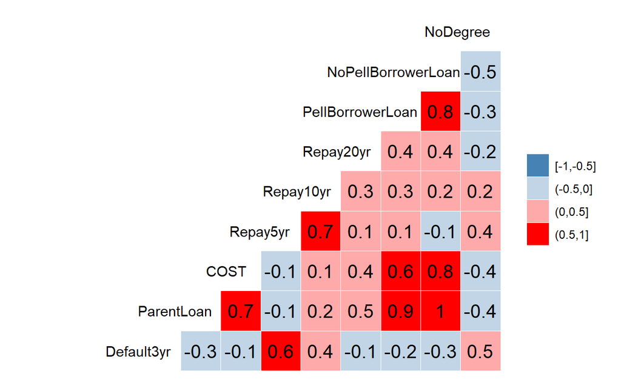

```r
library(GGally)
ggcorr(Default_Cor, nbreaks = 4,low = "steelblue", mid = "white", high = "red", label = TRUE, label_size = 5, hjust = 0.85, layout.exp = 3)
```

### Observation

```
        The two variableswith highest correlation coefficients (positively
        correlation) to default rates are:
        1.***Repay5yr, (cor 0.6)*** - Undergraduate Parent PLUS Loan
        dollar-based 5-year repayment rate
        2.***No Degree, (cor 0.5)***- Percentage of all students that did
        not receive an award and whose enrollment status is unknown after
        leaving this institution within 8 years of entry
```

# PREDICTING DEFAULT RATES

## Fig 5. Can default rates be predicted?

Method: Regression Analysis, Model Evaluation, Estimated Marginal Means (EMM) Post Hoc Test lm(formula = Default3yr ~ Repay5yr + NoDegree, data = Eloans)

Predicted values of a 3-year default rate using EMM (estimated marginal means) fitted with multiple linear regression model.

```r
Default1 <-lm(Default3yr~Repay5yr+NoDegree, data = Eloans)
```

```r
summary(Default1)
```

```
Call:
lm(formula = Default3yr ~ Repay5yr + NoDegree, data = Eloans)

Residuals:
      Min        1Q    Median        3Q       Max
-0.102440 -0.021622 -0.005443  0.016983  0.131494

Coefficients:
             Estimate Std. Error t value Pr(>|t|)
(Intercept) -0.041400   0.005007  -8.268 5.12e-16 ***
Repay5yr     0.139053   0.006954  19.995  < 2e-16 ***
NoDegree     0.111405   0.010970  10.155  < 2e-16 ***
---
Signif. codes:  0 '***' 0.001 '**' 0.01 '*' 0.05 '.' 0.1 ' ' 1

Residual standard error: 0.03111 on 862 degrees of freedom
Multiple R-squared:  0.4659,    Adjusted R-squared:  0.4646
F-statistic: 375.9 on 2 and 862 DF,  p-value: < 2.2e-16
```

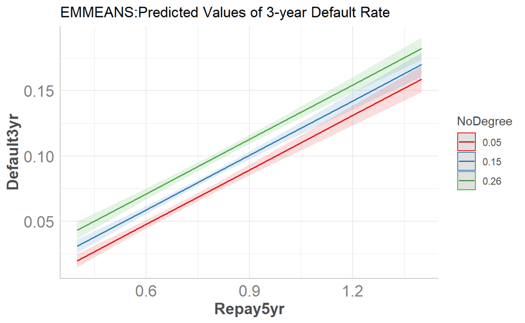

```r
library(ggeffects)
lm(Default3yr~Repay5yr+NoDegree, data = Eloans) %>%
  ggemmeans(terms = c("Repay5yr", "NoDegree")) %>%
  plot () +
  ggtitle( "EMMEANS:Predicted Values of 3-year Default Rate" )+
  theme(axis.text=element_text(size=14),
        axis.title=element_text(size=14,face="bold"))
```

### Observation

The mean percentage of undergraduate student Parent PLUS Loan borrowers in default after 3 years is 14.7%, with a max of 59% (Data from 2,766 institutions)

```
    HIGHER DEFAULT RATE FOR:
    -Parents  who entered a repayment plan within 5 years of loan disbursement AND
    -Parents whose students did not complete a degree
```

## MODEL EVALUATION -Diagnostic Plots

```r
Default_lm<- lm(Default3yr~Repay5yr+NoDegree, data=Eloans)
summary(Default_lm)
```

```
Call:
lm(formula = Default3yr ~ Repay5yr + NoDegree, data = Eloans)

Residuals:
      Min        1Q    Median        3Q       Max
-0.102440 -0.021622 -0.005443  0.016983  0.131494

Coefficients:
             Estimate Std. Error t value Pr(>|t|)
(Intercept) -0.041400   0.005007  -8.268 5.12e-16 ***
Repay5yr     0.139053   0.006954  19.995  < 2e-16 ***
NoDegree     0.111405   0.010970  10.155  < 2e-16 ***
---
Signif. codes:  0 '***' 0.001 '**' 0.01 '*' 0.05 '.' 0.1 ' ' 1

Residual standard error: 0.03111 on 862 degrees of freedom
Multiple R-squared:  0.4659,    Adjusted R-squared:  0.4646
F-statistic: 375.9 on 2 and 862 DF,  p-value: < 2.2e-16
```

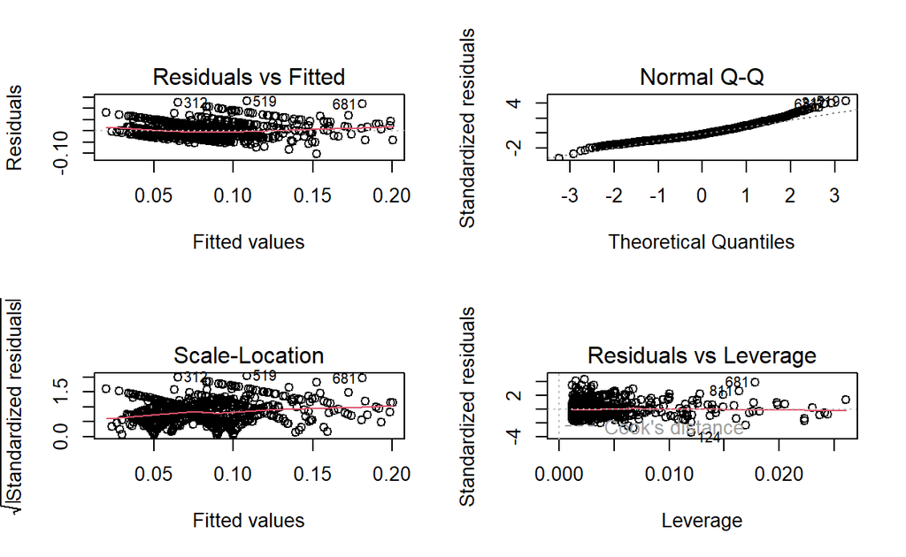

```r
par(mfrow=c(2,2))
plot(Default_lm)
```

## Assumptions: Multicollinearity and Heteroskedascity

```r
performance::check_collinearity(Default_lm)
```

```
# Check for Multicollinearity

Low Correlation

     Term  VIF Increased SE Tolerance
 Repay5yr 1.15         1.07      0.87
 NoDegree 1.15         1.07      0.87
```

## Low Correlation, No Multicollinearity, regression model is good.

```r
library(lmtest)
library(caret)
```

## Assumption: Heteroskesdacity, use Breusch-Pagan test

```r
lmtest::bptest(lm(Default3yr~NoDegree+Repay5yr, data=Eloans))
```

```
    studentized Breusch-Pagan test

data:  lm(Default3yr ~ NoDegree + Repay5yr, data = Eloans)
BP = 20.909, df = 2, p-value = 2.882e-05
```

*Result:* At p-value <0.05, homoscedasticity rejected in favor of heteroskedasticity

*Transformation:*

Transformed dependent variable using Box Cox Transformation and applied Breusch-Pagan test

```r
Default_BCMod <- caret::BoxCoxTrans(Eloans$Default3yr)
print(Default_BCMod)
```

```
Box-Cox Transformation

865 data points used to estimate Lambda

Input data summary:
   Min. 1st Qu.  Median    Mean 3rd Qu.    Max.
0.02000 0.05000 0.08000 0.08081 0.10000 0.30000

Largest/Smallest: 15
Sample Skewness: 1.18

Estimated Lambda: 0.1
With fudge factor, Lambda = 0 will be used for transformations
```

```r
NEloans <- cbind(Eloans, dist_new=predict(Default_BCMod, Eloans$Default3yr)) # append the transformed variable
head(NEloans) # view the top 6 rows
```

[output not shown]

[output cut: 48 more lines]

```r
lmMod_def <- lm(dist_new ~ NoDegree, data=NEloans)
bptest(lmMod_def)
```

```
    studentized Breusch-Pagan test

data:  lmMod_def
BP = 0.047752, df = 1, p-value = 0.827
```

*Result:* New p-value = 0.827 after transformation: homoscedasticity not rejected

## Evaluate New Diagnostic Plots using Box Cox Transformed Variable

```r
Default_lm2<- lm(dist_new~Repay5yr+NoDegree, data=NEloans)
summary(Default_lm2)
```

```
Call:
lm(formula = dist_new ~ Repay5yr + NoDegree, data = NEloans)

Residuals:
     Min       1Q   Median       3Q      Max
-1.20735 -0.25334 -0.01247  0.29037  1.17292

Coefficients:
            Estimate Std. Error t value Pr(>|t|)
(Intercept) -4.06186    0.06509 -62.402   <2e-16 ***
Repay5yr     1.58272    0.09041  17.507   <2e-16 ***
NoDegree     1.40450    0.14261   9.849   <2e-16 ***
---
Signif. codes:  0 '***' 0.001 '**' 0.01 '*' 0.05 '.' 0.1 ' ' 1

Residual standard error: 0.4045 on 862 degrees of freedom
Multiple R-squared:  0.4149,    Adjusted R-squared:  0.4135
F-statistic: 305.6 on 2 and 862 DF,  p-value: < 2.2e-16
```

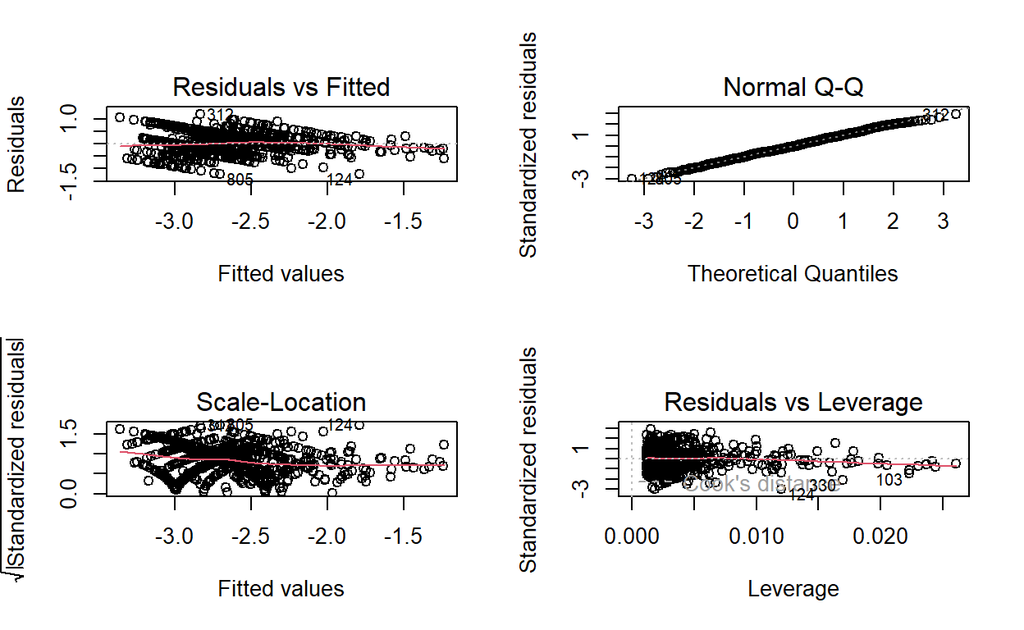

```r
par(mfrow=c(2,2))
plot(Default_lm2)
```

# CONCLUSION

With rising costs of education, parent PLUS loans have become increasing popular for families. The availability of parent PLUS loans have made post-secondary education accessible to more low- and moderate-income families. The mean cost of attendance per year is $38,144 and the mean parent PLUS loan is $24,131, with a max of $91,987 at an interest rate of 6.28%. According to the US Census Bureau, the median household income in the US is $67,521 The lack of limit of loan amounts and absence of debt-to-income ratio requirement have allowed parents to borrow more than their ability to repay. Comparison of parents of Pell grant recipients and non-Pell grant recipient borrower behavior is alarming. Most Pell grant recipient parents have income <$40,000 and median loan amount of $16,000, with a max of $95,089. Parents who entered repayment with 5 years of loan disbursement with students who did not complete the degree are most likely to default on the loan. This is likely due to personal circumstances such as family obligations or sought employment.

At a default rate of 14.7%, further analysis on this federal loan program is needed to better understand and prevent families from being entrapped in debt and exacerbate wealth disparities across races.

# LIMITATIONS OF THE STUDY

```
  -The College Scorecard has data on 6,694 institutions all over the US but
  this study is limited to only 865 schools due to missing data (e.g NULL and Privacy Suppressed).
  -The most recent data also discontinued collecting information relating to
  income, an important variable that could increase statistical power of this
  model.
  -The researcher used listwise deletion to handle the missing data. Due to
  the large size of the missing not at random (MNAR)  data, multiple
  imputation is not preferred as it may provide misleading results.
  -Regression model used to analyze default rates was limited to a couple of
  the variables with high correlation coefficients. The College Scorecard
  data is a very rich source of information. Unfortunately, the most recent
  data have discontinued releasing information on earnings and income.
  Further examination and analysis of underlying factors (e.g. race,
  first-generation students, gender, family characteristics) could probably
  increase the explanatory power of the model.
```

# FUTURE WORK: Loan Default Prediction using Decision Tree Classifier

Model currently has low accuracy, possible due to variance of continuous variables.Further work is needed.

```r
Eloans_train_test <- function(Eloans, size = 0.8, train = TRUE) {
    n_row = nrow(Eloans)
    total_row = size * n_row
    train_sample <- 1:total_row
    if (train == TRUE) {
        return (Eloans[train_sample, ])
    } else {
        return (Eloans[-train_sample, ])
    }
}
```

```r
Eloans_train <-Eloans_train_test(Eloans, 0.8, train = TRUE)
Eloans_test <- Eloans_train_test(Eloans, 0.8, train = FALSE)
dim(Eloans_train)
```

```
[1] 692  35
```

```r
dim(Eloans_test)
```

```
[1] 173  35
```

```r
prop.table(table(Eloans_train$Default3yr))
```

```
       0.02        0.03        0.04        0.05        0.06
0.031791908 0.044797688 0.075144509 0.235549133 0.062138728
       0.07        0.08        0.09         0.1        0.11
0.010115607 0.036127168 0.174855491 0.187861272 0.001445087
       0.12        0.14        0.16        0.17        0.18
0.011560694 0.069364162 0.007225434 0.002890173 0.002890173
       0.19         0.2        0.22        0.24         0.3
0.031791908 0.005780347 0.004335260 0.002890173 0.001445087
```

```r
prop.table(table(Eloans_test$Default3yr))
```

```
       0.02        0.03        0.04        0.05        0.06
0.046242775 0.075144509 0.075144509 0.260115607 0.069364162
       0.07        0.08        0.09         0.1        0.12
0.023121387 0.011560694 0.104046243 0.173410405 0.023121387
       0.14        0.16        0.18        0.19         0.2
0.057803468 0.017341040 0.005780347 0.040462428 0.005780347
       0.22        0.24
0.005780347 0.005780347
```

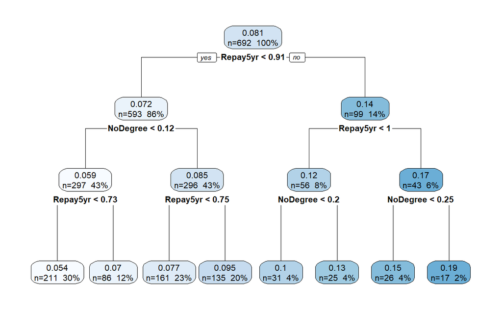

```r
library(rpart)
library(rpart.plot)
Eloansfit <- rpart(Default3yr~NoDegree+Repay5yr, data = Eloans_train, method = 'anova')
rpart.plot(Eloansfit, extra = 101)
```

```r
predict(Eloansfit, Eloans_train, type = 'vector')
```

[output not shown]

[output cut: 177 more lines]

[output not shown]

```r
predict_unseen <-predict(Eloansfit, Eloans_test, type = 'vector')
```

```r
Eloans_mat <- table(Eloans_test$Default3yr, predict_unseen)
Eloans_mat
```

```
      predict_unseen
       0.0538388625592417 0.0704651162790697 0.0774534161490683
  0.02                  5                  0                  3
  0.03                 10                  0                  3
  0.04                  3                  4                  4
  0.05                 15                  8                 17
  0.06                  1                  2                  5
  0.07                  0                  0                  1
  0.08                  0                  0                  0
  0.09                  1                  5                  3
  0.1                   4                  4                 11
  0.12                  0                  1                  0
  0.14                  0                  0                  0
  0.16                  0                  1                  0
  0.18                  0                  0                  0
  0.19                  0                  1                  3
  0.2                   0                  0                  0
  0.22                  0                  0                  0
  0.24                  0                  0                  0
      predict_unseen
       0.0946666666666665 0.101612903225806 0.132 0.148846153846154
  0.02                  0                 0     0                 0
  0.03                  0                 0     0                 0
  0.04                  2                 0     0                 0
  0.05                  4                 1     0                 0
  0.06                  3                 0     1                 0
  0.07                  3                 0     0                 0
  0.08                  2                 0     0                 0
  0.09                  6                 3     0                 0
  0.1                   9                 1     0                 1
  0.12                  2                 0     0                 0
  0.14                  6                 1     1                 1
  0.16                  0                 0     0                 1
  0.18                  0                 0     0                 1
  0.19                  1                 1     0                 0
  0.2                   0                 0     0                 0
  0.22                  0                 0     0                 1
  0.24                  0                 0     0                 0
      predict_unseen
       0.192941176470588
  0.02                 0
  0.03                 0
  0.04                 0
  0.05                 0
  0.06                 0
  0.07                 0
  0.08                 0
  0.09                 0
  0.1                  0
  0.12                 1
  0.14                 1
  0.16                 1
  0.18                 0
  0.19                 1
  0.2                  1
  0.22                 0
  0.24                 1
```

```r
accuracy_Test <- sum(diag(Eloans_mat)) / sum(Eloans_mat)
print(paste('Accuracy for test', accuracy_Test))
```

```
[1] "Accuracy for test 0.0751445086705202"
```

# FUTURE WORK: Loan Default Prediction using Random Forest

Random Forest using mtry=3 and 500 trees has been initiated Need to continue work on running and testing the model, confusionMatrix and importance plots

```r
Eloans <-select(Eloans,-c(INSTNM))
```

```r
library(randomForest)
library(caret)
library(e1071)
```

```r
Eloans.rf <- randomForest(Default3yr~ ., data = Eloans, mtry = 3,
                         importance = TRUE, na.action = na.omit)
print(Eloans.rf)
```

```
Call:
 randomForest(formula = Default3yr ~ ., data = Eloans, mtry = 3,      importance = TRUE, na.action = na.omit)
               Type of random forest: regression
                     Number of trees: 500
No. of variables tried at each split: 3

          Mean of squared residuals: 0.0003730025
                    % Var explained: 79.35
```

```r
Etrain_test <- function(Eloans, size = 0.8, train = TRUE) {
    n_row = nrow(Eloans)
    total_row = size * n_row
    train_sample <- 1:total_row
    if (train == TRUE) {
        return (Eloans[train_sample, ])
    } else {
        return (Eloans[-train_sample, ])
    }
}
```

```r
Etrain <-Etrain_test(Eloans, 0.8, train = TRUE)
Etest <- Etrain_test(Eloans, 0.8, train = FALSE)
dim(Etrain)
```

```
[1] 692  34
```

```r
dim(Etest)
```

```
[1] 173  34
```

```r
set.seed(120)  # Setting seed
classifier_RF <- randomForest(x = Etrain[-5],
                             y = Etrain$STABBR,
                             ntree = 500)

classifier_RF
```

```
Call:
 randomForest(x = Etrain[-5], y = Etrain$STABBR, ntree = 500)
               Type of random forest: unsupervised
                     Number of trees: 500
No. of variables tried at each split: 5
```

# REFERENCES

1. Data Home: College Scorecard. Data Home | College Scorecard. (n.d.). Retrieved May 11, 2022, from https://collegescorecard.ed.gov/data/
2. 2015–16 National Postsecondary Student Aid Study (npsas:16) student … (n.d.). Retrieved May 12, 2022, from https://nces.ed.gov/pubs2018/2018466.pdf
3. Federal Student Aid. (n.d.). Retrieved May 11, 2022, from https://studentaid.gov/plus-app/parent/landing
4. Wickham, H., & Grolemund, G. (2016). R for data science: Visualize, model, transform, tidy, and import data. OReilly Media.
5. R Core Team (2017). R: A language and environment for statistical computing. R Foundation for Statistical Computing, Vienna, Austria. URL https://www.R-project.org/.
6. [SMSS] Agresti, Alan. Statistical Methods for the Social Sciences. 5th Edition. Pearson, 2018. Wickham, H., & Grolemund, G. (2016). R for data science: Visualize, model, transform, tidy, and import data. OReilly Media

Comment on this article Share: